# Projekt 2 - Metaheurystyki w Zarządzaniu i Ekonomii - sprawozdanie

Piotr Gretszel

25 czerwca 2019

# Cel projektu

Celem ćwiczenia jest zbadanie działania własnoręcznie zaimplementowanego algorytmu genetycznego w symetrycznym problemie komiwojażera złożonym z 75 miast. Przedstawiono współrzędne 10 pierwszych miast:

```
##     X  Y
## 1  48 21
## 2  52 26
## 3  50 30
## 4  55 34
## 5  54 38
## 6  50 40
## 7  51 42
## 8  55 45
## 9  55 50
## 10 50 50
```

Najlepszym możliwym do uzyskania rezultatem dla badanego zbioru danych jest wynik **535**.

# Symetryczny problem komiwojażera

Nazwa pochodzi od typowej ilustracji problemu, przedstawiającej go z punktu widzenia wędrownego sprzedawcy (komiwojażera): Dane jest **n** miast, które komiwojażer ma odwiedzić, oraz odległość / cena podróży / czas podróży pomiędzy każdą parą miast. Celem jest znalezienie najkrótszej / najtańszej / najszybszej drogi łączącej wszystkie miasta, zaczynającej się i kończącej się w określonym punkcie.

Problem nazywany jest symetrycznym ponieważ odległość z miasta A do miasta B jest taka sama jak z miasta B do miasta A.

# Algorytm genetyczny

Jest to rodzaj heurystyki, która znajduje możliwie najlepsze rozwiązanie problemu w przestrzeni alternatywnych rozwiązań. Sposób działania algorytmów genetycznych przypomina zjawisko ewolucji biologicznej. Zaliczany jest do grupy algorytmów ewolucyjnych.

Przebieg algorytmu:

- Losowana jest populacja początkowa
- Populacja poddawana jest ocenie (selekcja metodą ruletki lub metody rankingowej). Najlepiej przystosowane osobniki biorą udział w procesie reprodukcji.
- Genotypy wybranych osobników są poddawane operatorom ewolucyjnym takim jak kojarzenie poprzez złączanie genotypów rodziców (krzyżowanie), czy mutacja, czyli wprowadzenie drobnych zmian losowych.
- Rodzi się kolejne pokolenie. Aby utrzymać stałą liczbę osobników w populacji, te najlepsze (według funkcji określającej fenotyp) są powielane, a najsłabsze usuwane. Jeżeli nie znaleziono dostatecznie dobrego rozwiązania, algorytm powraca do punktu drugiego. W przeciwnym wypadku wybierany jest najlepszy osobnik z populacji. Jego genotyp to uzyskany wynik.

# Przeprowadzone badanie

W badaniu pochylono się nad skutecznością zaimplementowanego algorytmu dla różnych parametrów. Wyniki zbadano pod kątem czasu wykonywania, najlepszego (najmniejszego) wyniku oraz najlepszej populacji. Algorytm został zaimplementowany w języku programowania C#. Cały kod źródłowy programu znajduje się w repozytorium pod linkiem [Github Piotr Gretszel](https://github.com/PiterCidry/Metaheuristics_in_Management_and_Economy)

Zastosowane parametry:

- *Iterations* - maksymalna liczba iteracji algorytmu (10000, 25000, 50000)
- *PopulationSize* - rozmiar populacji (20, 50, 100)
- *Pc* - prawdopodobieństwo zajścia krzyżowania (0.9, 0.7, 0.5)
- *Pm* - prawdopodobieństwo zajścia mutacji (0.1, 0.3, 0.5)
- *Pi* - prawdopodobieństwo zajścia inwersji (0.05, 0.1, 0.2)

# Wyniki badania

W wyniku skrzyżowania wszystkich kombinacji parametrów uzyskano ostatecznie 243 obserwacje. Zaprezentowano losowo wybrane 15 obserwacji wynikowych:

```
##      Iterations PopulationSize  Pc  Pm   Pi ElapsedMilliseconds BestGen
## 14        10000             20 0.7 0.3 0.10                5996    9673
## 119       25000             50 0.7 0.1 0.10               28010   23678
## 212       50000             50 0.5 0.3 0.10               49087   48731
## 14.1      10000             20 0.7 0.3 0.10                5996    9673
## 198       50000             50 0.9 0.5 0.20               65748   49039
## 219       50000            100 0.9 0.1 0.20              127489   48485
## 63        10000            100 0.9 0.5 0.20               26231    9943
## 41        10000             50 0.7 0.3 0.10               15363    9006
## 134       25000             50 0.5 0.5 0.10               24997   24257
## 187       50000             20 0.5 0.5 0.05               19960   49970
## 113       25000             50 0.9 0.3 0.10               32584   24759
## 238       50000            100 0.5 0.3 0.05               97657   37603
## 97        25000             20 0.7 0.5 0.05               11467   24253
## 99        25000             20 0.7 0.5 0.20               11472   22993
```

[output cut: 17 more lines]

Na wykresach pudełkowych zobrazowno kształtowanie się wyników w kategorii najlepszego dopasowania, najlepszej populacji oraz czasu trwania wykonywania algorytmu. Przedstawiono również podstawowe statystyki opisowe dla lepszego zobrazowania wykresów:

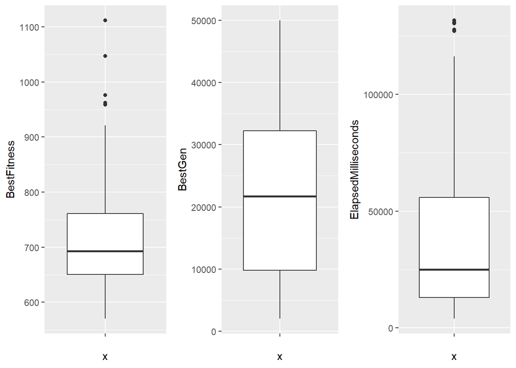

```
##   BestFitness        BestGen      ElapsedMilliseconds
##  Min.   : 570.0   Min.   : 2013   Min.   :  3918
##  1st Qu.: 650.5   1st Qu.: 9775   1st Qu.: 12996
##  Median : 693.0   Median :21725   Median : 25058
##  Mean   : 712.1   Mean   :22761   Mean   : 37383
##  3rd Qu.: 761.0   3rd Qu.:32249   3rd Qu.: 55849
##  Max.   :1112.0   Max.   :49978   Max.   :131698
```

Jak widać mediana najlepszego dopasowania wynosiła 693. Kwartyl dolny około 650 a górny 761. Występowały również obserwacje odstające dla najgorszych dopasowań. Najgorsze dopasowanie wyniosło 1112.

Średnia najlepszej populacji kształtowała się na poziomie 22761. Rozstęp międzykwartylowy wyniósł około 22000. Minimalna najniższa liczba populacji wyniosła około 2000 a najwyższa 50000.

Przedstawiono histogramy dla dwóch zmiennych wynikowych, czyli dla najlepszej generacji i najlepszego dopasowania. Wnioski z nich częściowo pokrywają się z wnioskami z wykresów pudełkowych.

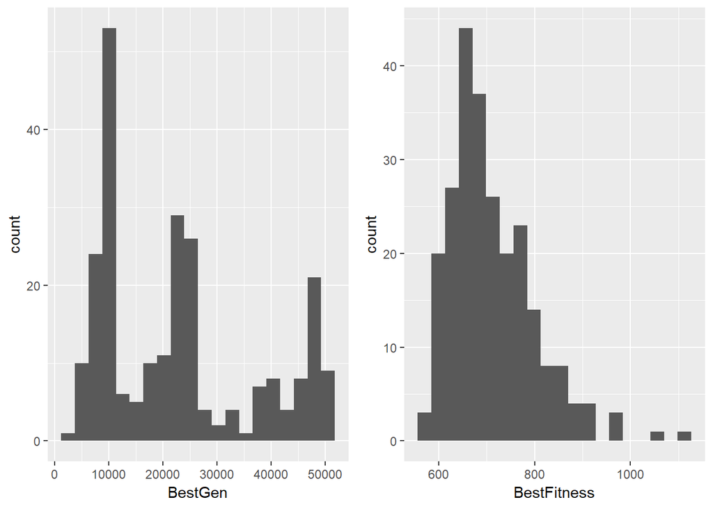

Warto zauważyć, że wyniki dla najlepszej generacji zebrały się w 3 skupiska. Może to być spowodowane wpływem pozostałych parametrów wejściowych, które często były złożone z 3 różnych wartości.

Nie stwierdzono wyraźnej zależności pomiędzy najlepszą generacją a najlepszym dopasowaniem. Zarówno dla małych jak i dużych generacji występują dopasowania dobre i słabe. Obrazuje to następujący wykres:

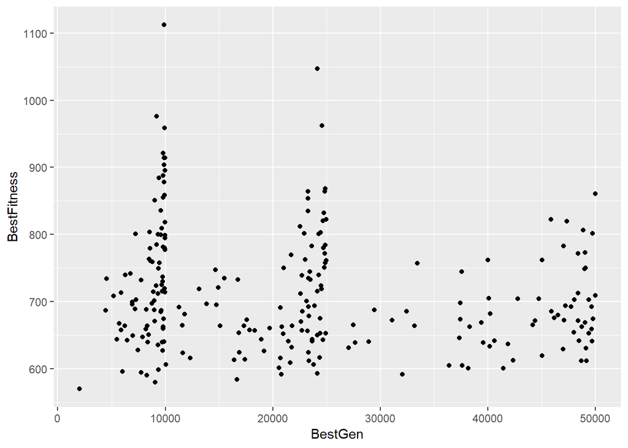

Przedstawiono wykresy zależności pomiędzy parametrami (i zmiennymi wynikowymi) a czasem wykonywania algorytmu:

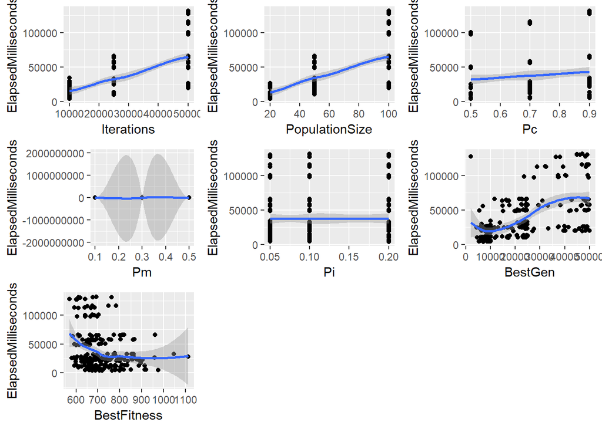

O istotnej zależności (wydłużeniu) czasu wykonywania mówić można w przypadku zwiększania liczby iteracji, zwiększania liczności populacji. W przypadku pozostałych parametru zależność nie jest widoczna. Zauważyć można, że im większa najlepsza generacja tym z reguły dłuższy czas wykonywania algorytmu. Co ciekawe, dla najlepszych dopasowań (najniższych) czas wykonywania był istotnie dłuższy.

Zobrazowano zależność pomiędzy najlepszym (najniższym) uzyskanym dopasowaniem a poszczególnymi parametrami:

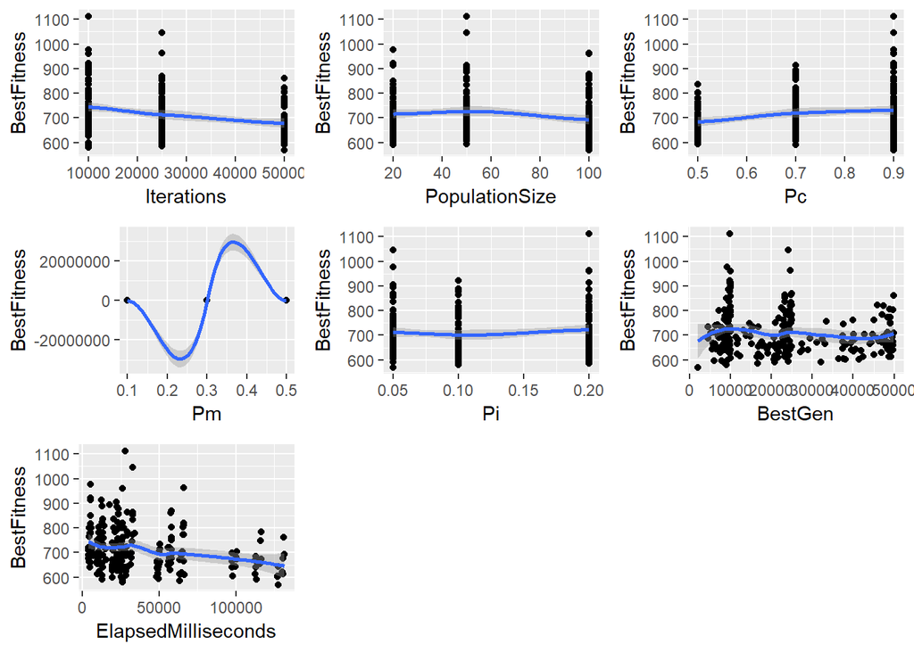

Z powyższych wykresów nie można wyciągnąć wniosku, że dla jakiegoś parametru (o pewnej wartości) uzyskany wynik był istotnie lepszy.

# Podsumowanie

Powyższe rozważania nie pozwoliły odpowiedzieć na pytanie, jakie powinny być parametry w algorytmie genetycznym, tak aby zmaksymalizować szansę na uzyskanie zadowalającego rezultatu w problemie symetrycznym komiwojażera. Zasugerowały one natomiast kierunek zależności pomiędzy czasem wykonywania a parametrami. Z reguły, im wyższa wartość parametrów takich jak liczba iteracji, czy liczność populacji, tym dłużej wykonywał się algorytm.

Na zakończenie przedstawiono parametry, dla których w toku badania uzyskano najlepszy wynik:

```
##     Iterations PopulationSize  Pc  Pm   Pi ElapsedMilliseconds BestGen
## 220      50000            100 0.9 0.3 0.05              127722    2013
##     BestFitness
## 220         570
```

Najlepszy wynik **570** uzyskano dla parametrów następujących:

- Liczba iteracji: 50000
- Rozmiar populacji: 100
- Prawdopodobieństwo krzyżowania: 90%
- Prawdopodobieństwo mutacji: 30%
- Prawdopodobieństwo inwersji: 5%

Algorytm z takimi parametrami dał zadowalający wynik w 2013 generacji a wykonywał się ponad 2 minuty.